# Variation in Light Bulb Intensity Measurement

Math 119 Class

1/12/2021

We read in a data for 202 light bulbs measured at 2104 hours after the light bulbs was turned on. The data includes the id of the light bulb, the time (2104), the intensity of the light bulb measured in lumens, and the intensity of the light bulb as a percent of the original lumens recorded as a proportion.

We would like to have the percent intensities recorded as percents. So we multiply all of the currently recorded values for percent intensity by 100.

```r
library(data4led)
dist <- led_time(2100)

dist$percent_intensity <- dist$percent_intensity*100
```

We are interested in the variation of the measurements for these light bulbs after 2104 hours. We can visualize this variation using the following density histogram.

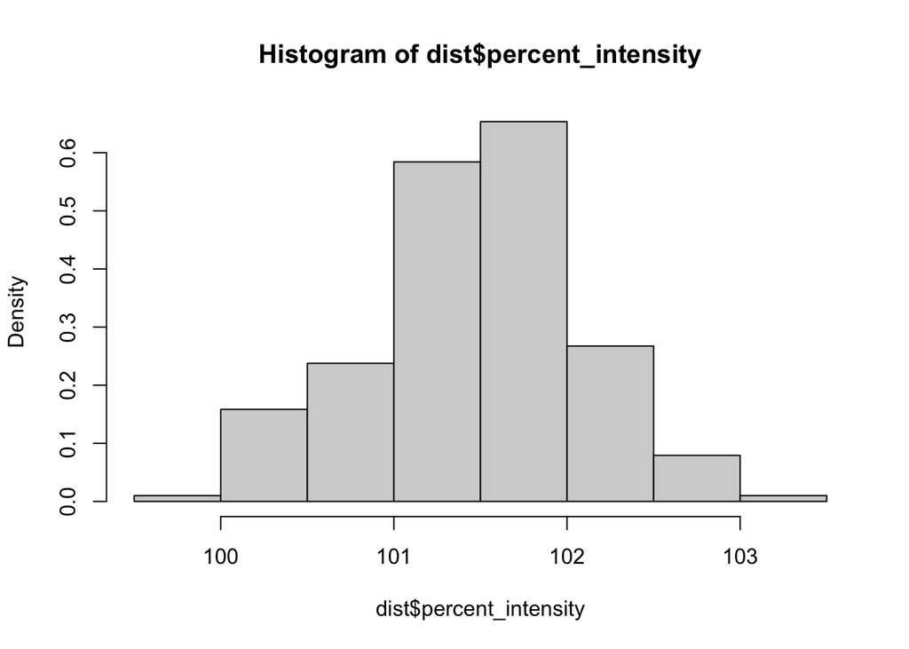

```r
hist(dist$percent_intensity,probability = TRUE)
```